# Explore Movie Dataset

## 探索电影数据集

在这个项目中，你将尝试使用所学的知识，使用 `NumPy`、`Pandas`、`matplotlib`、`seaborn` 库中的函数，来对电影数据集进行探索。

下载数据集： [TMDb电影数据](https://s3.cn-north-1.amazonaws.com.cn/static-documents/nd101/explore+dataset/tmdb-movies.csv)

数据集各列名称的含义：

| 列名称 | id | imdb_id | popularity | budget | revenue | original_title | cast | homepage | director | tagline | keywords | overview | runtime | genres | production_companies | release_date | vote_count | vote_average | release_year | budget_adj | revenue_adj |
| --- | --- | --- | --- | --- | --- | --- | --- | --- | --- | --- | --- | --- | --- | --- | --- | --- | --- | --- | --- | --- | --- |
| 含义 | 编号 | IMDB 编号 | 知名度 | 预算 | 票房 | 名称 | 主演 | 网站 | 导演 | 宣传词 | 关键词 | 简介 | 时常 | 类别 | 发行公司 | 发行日期 | 投票总数 | 投票均值 | 发行年份 | 预算（调整后） | 票房（调整后） |

**请注意，你需要提交该报告导出的 `.html`、`.ipynb` 以及 `.py` 文件。**

## 第一节 数据的导入与处理

在这一部分，你需要编写代码，使用 Pandas 读取数据，并进行预处理。

**任务1.1：** 导入库以及数据

1. 载入需要的库 `NumPy`、`Pandas`、`matplotlib`、`seaborn`。
2. 利用 `Pandas` 库，读取 `tmdb-movies.csv` 中的数据，保存为 `movie_data`。

提示：记得使用 notebook 中的魔法指令 `%matplotlib inline`，否则会导致你接下来无法打印出图像。

```python
import numpy as np
import pandas as pd
import matplotlib.pyplot as plt # 不要忘记 pyplot
import seaborn as sb
%matplotlib inline
movie_data = pd.read_csv('tmdb-movies.csv')
```

**任务1.2:** 了解数据

你会接触到各种各样的数据表，因此在读取之后，我们有必要通过一些简单的方法，来了解我们数据表是什么样子的。

1. 获取数据表的行列，并打印。
2. 使用 `.head()`、`.tail()`、`.sample()` 方法，观察、了解数据表的情况。
3. 使用 `.dtypes` 属性，来查看各列数据的数据类型。
4. 使用 `isnull()` 配合 `.any()` 等方法，来查看各列是否存在空值。
5. 使用 `.describe()` 方法，看看数据表中数值型的数据是怎么分布的。

```python
movie_data.info()
```

```
<class 'pandas.core.frame.DataFrame'>
RangeIndex: 10866 entries, 0 to 10865
Data columns (total 21 columns):
id                      10866 non-null int64
imdb_id                 10856 non-null object
popularity              10866 non-null float64
budget                  10866 non-null int64
revenue                 10866 non-null int64
original_title          10866 non-null object
cast                    10790 non-null object
homepage                2936 non-null object
director                10822 non-null object
tagline                 8042 non-null object
keywords                9373 non-null object
overview                10862 non-null object
runtime                 10866 non-null int64
genres                  10843 non-null object
production_companies    9836 non-null object
release_date            10866 non-null object
vote_count              10866 non-null int64
vote_average            10866 non-null float64
release_year            10866 non-null int64
budget_adj              10866 non-null float64
revenue_adj             10866 non-null float64
dtypes: float64(4), int64(6), object(11)
memory usage: 1.7+ MB
```

**任务1.3:** 清理数据

在真实的工作场景中，数据处理往往是最为费时费力的环节。但是幸运的是，我们提供给大家的 tmdb 数据集非常的「干净」，不需要大家做特别多的数据清洗以及处理工作。在这一步中，你的核心的工作主要是对数据表中的空值进行处理。你可以使用 `.fillna()` 来填补空值，当然也可以使用 `.dropna()` 来丢弃数据表中包含空值的某些行或者列。

任务：使用适当的方法来清理空值，并将得到的数据保存。

```python
#结合 movie_data 缺失值分布的特点，为尽量保证数据的完整性，
#首先删除缺失较为严重且无关紧要的列：'homepage','tagline','keywords','production_companies'
#进而删除轻微缺失的行：‘imdb_id’，‘cast’，‘director’，‘overview’，‘genres’
new_data = movie_data.drop(columns = ['homepage','tagline','keywords','production_companies'])
new_data.dropna(axis = 0, inplace = True)
new_data.shape[0]
#movie_data 中一共10866项，经缺失值处理后剩余10725项，得到了较好的保留
```

```
10725
```

```python
new_data.head()
```

|  | id | imdb_id | popularity | budget | revenue | original_title | cast | director | overview | runtime | genres | release_date | vote_count | vote_average | release_year | budget_adj | revenue_adj |
| --- | --- | --- | --- | --- | --- | --- | --- | --- | --- | --- | --- | --- | --- | --- | --- | --- | --- |
| 0 | 135397 | tt0369610 | 32.985763 | 150000000 | 1513528810 | Jurassic World | Chris Pratt\|Bryce Dallas Howard\|Irrfan Khan\|Vi... | Colin Trevorrow | Twenty-two years after the events of Jurassic ... | 124 | Action\|Adventure\|Science Fiction\|Thriller | 6/9/15 | 5562 | 6.5 | 2015 | 1.379999e+08 | 1.392446e+09 |
| 1 | 76341 | tt1392190 | 28.419936 | 150000000 | 378436354 | Mad Max: Fury Road | Tom Hardy\|Charlize Theron\|Hugh Keays-Byrne\|Nic... | George Miller | An apocalyptic story set in the furthest reach... | 120 | Action\|Adventure\|Science Fiction\|Thriller | 5/13/15 | 6185 | 7.1 | 2015 | 1.379999e+08 | 3.481613e+08 |
| 2 | 262500 | tt2908446 | 13.112507 | 110000000 | 295238201 | Insurgent | Shailene Woodley\|Theo James\|Kate Winslet\|Ansel... | Robert Schwentke | Beatrice Prior must confront her inner demons ... | 119 | Adventure\|Science Fiction\|Thriller | 3/18/15 | 2480 | 6.3 | 2015 | 1.012000e+08 | 2.716190e+08 |
| 3 | 140607 | tt2488496 | 11.173104 | 200000000 | 2068178225 | Star Wars: The Force Awakens | Harrison Ford\|Mark Hamill\|Carrie Fisher\|Adam D... | J.J. Abrams | Thirty years after defeating the Galactic Empi... | 136 | Action\|Adventure\|Science Fiction\|Fantasy | 12/15/15 | 5292 | 7.5 | 2015 | 1.839999e+08 | 1.902723e+09 |
| 4 | 168259 | tt2820852 | 9.335014 | 190000000 | 1506249360 | Furious 7 | Vin Diesel\|Paul Walker\|Jason Statham\|Michelle ... | James Wan | Deckard Shaw seeks revenge against Dominic Tor... | 137 | Action\|Crime\|Thriller | 4/1/15 | 2947 | 7.3 | 2015 | 1.747999e+08 | 1.385749e+09 |

## 第二节 根据指定要求读取数据

相比 Excel 等数据分析软件，Pandas 的一大特长在于，能够轻松地基于复杂的逻辑选择合适的数据。因此，如何根据指定的要求，从数据表当获取适当的数据，是使用 Pandas 中非常重要的技能，也是本节重点考察大家的内容。

**任务2.1:** 简单读取

1. 读取数据表中名为 `id`、`popularity`、`budget`、`runtime`、`vote_average` 列的数据。
2. 读取数据表中前1～20行以及48、49行的数据。
3. 读取数据表中第50～60行的 `popularity` 那一列的数据。

要求：每一个语句只能用一行代码实现。

```python
#读取数据表中名为 id、popularity、budget、runtime、vote_average 列的数据。
new_data[['id','popularity','budget','runtime','vote_average']].head(10)
```

|  | id | popularity | budget | runtime | vote_average |
| --- | --- | --- | --- | --- | --- |
| 0 | 135397 | 32.985763 | 150000000 | 124 | 6.5 |
| 1 | 76341 | 28.419936 | 150000000 | 120 | 7.1 |
| 2 | 262500 | 13.112507 | 110000000 | 119 | 6.3 |
| 3 | 140607 | 11.173104 | 200000000 | 136 | 7.5 |
| 4 | 168259 | 9.335014 | 190000000 | 137 | 7.3 |
| 5 | 281957 | 9.110700 | 135000000 | 156 | 7.2 |
| 6 | 87101 | 8.654359 | 155000000 | 125 | 5.8 |
| 7 | 286217 | 7.667400 | 108000000 | 141 | 7.6 |
| 8 | 211672 | 7.404165 | 74000000 | 91 | 6.5 |
| 9 | 150540 | 6.326804 | 175000000 | 94 | 8.0 |

```python
#读取数据表中前1～20行以及48、49行的数据。
new_data.loc[list(range(20))+[47,48]]
```

|  | id | imdb_id | popularity | budget | revenue | original_title | cast | director | overview | runtime | genres | release_date | vote_count | vote_average | release_year | budget_adj | revenue_adj |
| --- | --- | --- | --- | --- | --- | --- | --- | --- | --- | --- | --- | --- | --- | --- | --- | --- | --- |
| 0 | 135397 | tt0369610 | 32.985763 | 150000000 | 1513528810 | Jurassic World | Chris Pratt\|Bryce Dallas Howard\|Irrfan Khan\|Vi... | Colin Trevorrow | Twenty-two years after the events of Jurassic ... | 124 | Action\|Adventure\|Science Fiction\|Thriller | 6/9/15 | 5562 | 6.5 | 2015 | 1.379999e+08 | 1.392446e+09 |
| 1 | 76341 | tt1392190 | 28.419936 | 150000000 | 378436354 | Mad Max: Fury Road | Tom Hardy\|Charlize Theron\|Hugh Keays-Byrne\|Nic... | George Miller | An apocalyptic story set in the furthest reach... | 120 | Action\|Adventure\|Science Fiction\|Thriller | 5/13/15 | 6185 | 7.1 | 2015 | 1.379999e+08 | 3.481613e+08 |
| 2 | 262500 | tt2908446 | 13.112507 | 110000000 | 295238201 | Insurgent | Shailene Woodley\|Theo James\|Kate Winslet\|Ansel... | Robert Schwentke | Beatrice Prior must confront her inner demons ... | 119 | Adventure\|Science Fiction\|Thriller | 3/18/15 | 2480 | 6.3 | 2015 | 1.012000e+08 | 2.716190e+08 |
| 3 | 140607 | tt2488496 | 11.173104 | 200000000 | 2068178225 | Star Wars: The Force Awakens | Harrison Ford\|Mark Hamill\|Carrie Fisher\|Adam D... | J.J. Abrams | Thirty years after defeating the Galactic Empi... | 136 | Action\|Adventure\|Science Fiction\|Fantasy | 12/15/15 | 5292 | 7.5 | 2015 | 1.839999e+08 | 1.902723e+09 |
| 4 | 168259 | tt2820852 | 9.335014 | 190000000 | 1506249360 | Furious 7 | Vin Diesel\|Paul Walker\|Jason Statham\|Michelle ... | James Wan | Deckard Shaw seeks revenge against Dominic Tor... | 137 | Action\|Crime\|Thriller | 4/1/15 | 2947 | 7.3 | 2015 | 1.747999e+08 | 1.385749e+09 |
| 5 | 281957 | tt1663202 | 9.110700 | 135000000 | 532950503 | The Revenant | Leonardo DiCaprio\|Tom Hardy\|Will Poulter\|Domhn... | Alejandro González Iñárritu | In the 1820s, a frontiersman, Hugh Glass, sets... | 156 | Western\|Drama\|Adventure\|Thriller | 12/25/15 | 3929 | 7.2 | 2015 | 1.241999e+08 | 4.903142e+08 |
| 6 | 87101 | tt1340138 | 8.654359 | 155000000 | 440603537 | Terminator Genisys | Arnold Schwarzenegger\|Jason Clarke\|Emilia Clar... | Alan Taylor | The year is 2029. John Connor, leader of the r... | 125 | Science Fiction\|Action\|Thriller\|Adventure | 6/23/15 | 2598 | 5.8 | 2015 | 1.425999e+08 | 4.053551e+08 |
| 7 | 286217 | tt3659388 | 7.667400 | 108000000 | 595380321 | The Martian | Matt Damon\|Jessica Chastain\|Kristen Wiig\|Jeff ... | Ridley Scott | During a manned mission to Mars, Astronaut Mar... | 141 | Drama\|Adventure\|Science Fiction | 9/30/15 | 4572 | 7.6 | 2015 | 9.935996e+07 | 5.477497e+08 |
| 8 | 211672 | tt2293640 | 7.404165 | 74000000 | 1156730962 | Minions | Sandra Bullock\|Jon Hamm\|Michael Keaton\|Allison... | Kyle Balda\|Pierre Coffin | Minions Stuart, Kevin and Bob are recruited by... | 91 | Family\|Animation\|Adventure\|Comedy | 6/17/15 | 2893 | 6.5 | 2015 | 6.807997e+07 | 1.064192e+09 |
| 9 | 150540 | tt2096673 | 6.326804 | 175000000 | 853708609 | Inside Out | Amy Poehler\|Phyllis Smith\|Richard Kind\|Bill Ha... | Pete Docter | Growing up can be a bumpy road, and it's no ex... | 94 | Comedy\|Animation\|Family | 6/9/15 | 3935 | 8.0 | 2015 | 1.609999e+08 | 7.854116e+08 |
| 10 | 206647 | tt2379713 | 6.200282 | 245000000 | 880674609 | Spectre | Daniel Craig\|Christoph Waltz\|Léa Seydoux\|Ralp... | Sam Mendes | A cryptic message from Bond’s past sends him... | 148 | Action\|Adventure\|Crime | 10/26/15 | 3254 | 6.2 | 2015 | 2.253999e+08 | 8.102203e+08 |
| 11 | 76757 | tt1617661 | 6.189369 | 176000003 | 183987723 | Jupiter Ascending | Mila Kunis\|Channing Tatum\|Sean Bean\|Eddie Redm... | Lana Wachowski\|Lilly Wachowski | In a universe where human genetic material is ... | 124 | Science Fiction\|Fantasy\|Action\|Adventure | 2/4/15 | 1937 | 5.2 | 2015 | 1.619199e+08 | 1.692686e+08 |
| 12 | 264660 | tt0470752 | 6.118847 | 15000000 | 36869414 | Ex Machina | Domhnall Gleeson\|Alicia Vikander\|Oscar Isaac\|S... | Alex Garland | Caleb, a 26 year old coder at the world's larg... | 108 | Drama\|Science Fiction | 1/21/15 | 2854 | 7.6 | 2015 | 1.379999e+07 | 3.391985e+07 |
| 13 | 257344 | tt2120120 | 5.984995 | 88000000 | 243637091 | Pixels | Adam Sandler\|Michelle Monaghan\|Peter Dinklage\|... | Chris Columbus | Video game experts are recruited by the milita... | 105 | Action\|Comedy\|Science Fiction | 7/16/15 | 1575 | 5.8 | 2015 | 8.095996e+07 | 2.241460e+08 |
| 14 | 99861 | tt2395427 | 5.944927 | 280000000 | 1405035767 | Avengers: Age of Ultron | Robert Downey Jr.\|Chris Hemsworth\|Mark Ruffalo... | Joss Whedon | When Tony Stark tries to jumpstart a dormant p... | 141 | Action\|Adventure\|Science Fiction | 4/22/15 | 4304 | 7.4 | 2015 | 2.575999e+08 | 1.292632e+09 |
| 15 | 273248 | tt3460252 | 5.898400 | 44000000 | 155760117 | The Hateful Eight | Samuel L. Jackson\|Kurt Russell\|Jennifer Jason ... | Quentin Tarantino | Bounty hunters seek shelter from a raging bliz... | 167 | Crime\|Drama\|Mystery\|Western | 12/25/15 | 2389 | 7.4 | 2015 | 4.047998e+07 | 1.432992e+08 |
| 16 | 260346 | tt2446042 | 5.749758 | 48000000 | 325771424 | Taken 3 | Liam Neeson\|Forest Whitaker\|Maggie Grace\|Famke... | Olivier Megaton | Ex-government operative Bryan Mills finds his ... | 109 | Crime\|Action\|Thriller | 1/1/15 | 1578 | 6.1 | 2015 | 4.415998e+07 | 2.997096e+08 |
| 17 | 102899 | tt0478970 | 5.573184 | 130000000 | 518602163 | Ant-Man | Paul Rudd\|Michael Douglas\|Evangeline Lilly\|Cor... | Peyton Reed | Armed with the astonishing ability to shrink i... | 115 | Science Fiction\|Action\|Adventure | 7/14/15 | 3779 | 7.0 | 2015 | 1.195999e+08 | 4.771138e+08 |
| 18 | 150689 | tt1661199 | 5.556818 | 95000000 | 542351353 | Cinderella | Lily James\|Cate Blanchett\|Richard Madden\|Helen... | Kenneth Branagh | When her father unexpectedly passes away, youn... | 112 | Romance\|Fantasy\|Family\|Drama | 3/12/15 | 1495 | 6.8 | 2015 | 8.739996e+07 | 4.989630e+08 |
| 19 | 131634 | tt1951266 | 5.476958 | 160000000 | 650523427 | The Hunger Games: Mockingjay - Part 2 | Jennifer Lawrence\|Josh Hutcherson\|Liam Hemswor... | Francis Lawrence | With the nation of Panem in a full scale war, ... | 136 | War\|Adventure\|Science Fiction | 11/18/15 | 2380 | 6.5 | 2015 | 1.471999e+08 | 5.984813e+08 |
| 47 | 286565 | tt3622592 | 2.968254 | 12000000 | 85512300 | Paper Towns | Nat Wolff\|Cara Delevingne\|Halston Sage\|Justice... | Jake Schreier | Quentin Jacobsen has spent a lifetime loving t... | 109 | Drama\|Mystery\|Romance | 7/9/15 | 1252 | 6.2 | 2015 | 1.104000e+07 | 7.867128e+07 |
| 48 | 265208 | tt2231253 | 2.932340 | 30000000 | 0 | Wild Card | Jason Statham\|Michael Angarano\|Milo Ventimigli... | Simon West | When a Las Vegas bodyguard with lethal skills ... | 92 | Thriller\|Crime\|Drama | 1/14/15 | 481 | 5.3 | 2015 | 2.759999e+07 | 0.000000e+00 |

```python
#读取数据表中第50～60行的 popularity 那一列的数据。
new_data.loc[49:59, 'popularity']#切片，含尾
```

```
49    2.885126
50    2.883233
51    2.814802
52    2.798017
53    2.793297
54    2.614499
55    2.584264
56    2.578919
57    2.575711
58    2.557859
59    2.550747
Name: popularity, dtype: float64
```

# ---

**任务2.2:** 逻辑读取（Logical Indexing）

1. 读取数据表中 **`popularity` 大于5** 的所有数据。
2. 读取数据表中 **`popularity` 大于5** 的所有数据且**发行年份在1996年之后**的所有数据。

提示：Pandas 中的逻辑运算符如 `&`、`|`，分别代表`且`以及`或`。

要求：请使用 Logical Indexing实现。

```python
#读取数据表中 popularity 大于5 的所有数据。
new_data[new_data['popularity'] > 5].head()
```

|  | id | imdb_id | popularity | budget | revenue | original_title | cast | director | overview | runtime | genres | release_date | vote_count | vote_average | release_year | budget_adj | revenue_adj |
| --- | --- | --- | --- | --- | --- | --- | --- | --- | --- | --- | --- | --- | --- | --- | --- | --- | --- |
| 0 | 135397 | tt0369610 | 32.985763 | 150000000 | 1513528810 | Jurassic World | Chris Pratt\|Bryce Dallas Howard\|Irrfan Khan\|Vi... | Colin Trevorrow | Twenty-two years after the events of Jurassic ... | 124 | Action\|Adventure\|Science Fiction\|Thriller | 6/9/15 | 5562 | 6.5 | 2015 | 1.379999e+08 | 1.392446e+09 |
| 1 | 76341 | tt1392190 | 28.419936 | 150000000 | 378436354 | Mad Max: Fury Road | Tom Hardy\|Charlize Theron\|Hugh Keays-Byrne\|Nic... | George Miller | An apocalyptic story set in the furthest reach... | 120 | Action\|Adventure\|Science Fiction\|Thriller | 5/13/15 | 6185 | 7.1 | 2015 | 1.379999e+08 | 3.481613e+08 |
| 2 | 262500 | tt2908446 | 13.112507 | 110000000 | 295238201 | Insurgent | Shailene Woodley\|Theo James\|Kate Winslet\|Ansel... | Robert Schwentke | Beatrice Prior must confront her inner demons ... | 119 | Adventure\|Science Fiction\|Thriller | 3/18/15 | 2480 | 6.3 | 2015 | 1.012000e+08 | 2.716190e+08 |
| 3 | 140607 | tt2488496 | 11.173104 | 200000000 | 2068178225 | Star Wars: The Force Awakens | Harrison Ford\|Mark Hamill\|Carrie Fisher\|Adam D... | J.J. Abrams | Thirty years after defeating the Galactic Empi... | 136 | Action\|Adventure\|Science Fiction\|Fantasy | 12/15/15 | 5292 | 7.5 | 2015 | 1.839999e+08 | 1.902723e+09 |
| 4 | 168259 | tt2820852 | 9.335014 | 190000000 | 1506249360 | Furious 7 | Vin Diesel\|Paul Walker\|Jason Statham\|Michelle ... | James Wan | Deckard Shaw seeks revenge against Dominic Tor... | 137 | Action\|Crime\|Thriller | 4/1/15 | 2947 | 7.3 | 2015 | 1.747999e+08 | 1.385749e+09 |

```python
#读取数据表中 popularity 大于5 的所有数据且发行年份在1996年之后的所有数据。
new_data[(new_data['popularity'] >5) & (new_data['release_year'] >= 1996)].head()
```

|  | id | imdb_id | popularity | budget | revenue | original_title | cast | director | overview | runtime | genres | release_date | vote_count | vote_average | release_year | budget_adj | revenue_adj |
| --- | --- | --- | --- | --- | --- | --- | --- | --- | --- | --- | --- | --- | --- | --- | --- | --- | --- |
| 0 | 135397 | tt0369610 | 32.985763 | 150000000 | 1513528810 | Jurassic World | Chris Pratt\|Bryce Dallas Howard\|Irrfan Khan\|Vi... | Colin Trevorrow | Twenty-two years after the events of Jurassic ... | 124 | Action\|Adventure\|Science Fiction\|Thriller | 6/9/15 | 5562 | 6.5 | 2015 | 1.379999e+08 | 1.392446e+09 |
| 1 | 76341 | tt1392190 | 28.419936 | 150000000 | 378436354 | Mad Max: Fury Road | Tom Hardy\|Charlize Theron\|Hugh Keays-Byrne\|Nic... | George Miller | An apocalyptic story set in the furthest reach... | 120 | Action\|Adventure\|Science Fiction\|Thriller | 5/13/15 | 6185 | 7.1 | 2015 | 1.379999e+08 | 3.481613e+08 |
| 2 | 262500 | tt2908446 | 13.112507 | 110000000 | 295238201 | Insurgent | Shailene Woodley\|Theo James\|Kate Winslet\|Ansel... | Robert Schwentke | Beatrice Prior must confront her inner demons ... | 119 | Adventure\|Science Fiction\|Thriller | 3/18/15 | 2480 | 6.3 | 2015 | 1.012000e+08 | 2.716190e+08 |
| 3 | 140607 | tt2488496 | 11.173104 | 200000000 | 2068178225 | Star Wars: The Force Awakens | Harrison Ford\|Mark Hamill\|Carrie Fisher\|Adam D... | J.J. Abrams | Thirty years after defeating the Galactic Empi... | 136 | Action\|Adventure\|Science Fiction\|Fantasy | 12/15/15 | 5292 | 7.5 | 2015 | 1.839999e+08 | 1.902723e+09 |
| 4 | 168259 | tt2820852 | 9.335014 | 190000000 | 1506249360 | Furious 7 | Vin Diesel\|Paul Walker\|Jason Statham\|Michelle ... | James Wan | Deckard Shaw seeks revenge against Dominic Tor... | 137 | Action\|Crime\|Thriller | 4/1/15 | 2947 | 7.3 | 2015 | 1.747999e+08 | 1.385749e+09 |

**任务2.3:** 分组读取

1. 对 `release_year` 进行分组，使用 [`.agg`](http://pandas.pydata.org/pandas-docs/version/0.22/generated/pandas.core.groupby.DataFrameGroupBy.agg.html) 获得 `revenue` 的均值。
2. 对 `director` 进行分组，使用 [`.agg`](http://pandas.pydata.org/pandas-docs/version/0.22/generated/pandas.core.groupby.DataFrameGroupBy.agg.html) 获得 `popularity` 的均值，从高到低排列。

要求：使用 `Groupby` 命令实现。

```python
#对 release_year 进行分组，使用 .agg 获得 revenue 的均值。
new_data.groupby(new_data['release_year'])['revenue'].mean().head()
```

```
release_year
1960    4.531406e+06
1961    1.089420e+07
1962    6.736870e+06
1963    5.511911e+06
1964    8.118614e+06
Name: revenue, dtype: float64
```

```python
#对 director 进行分组，使用 .agg 获得 popularity 的均值，从高到低排列。
new_data.groupby(new_data['director'])['popularity'].mean().sort_values(ascending=False).head()
```

```
director
Colin Trevorrow                16.696886
Joe Russo|Anthony Russo        12.971027
Chad Stahelski|David Leitch    11.422751
Don Hall|Chris Williams         8.691294
Juno John Lee                   8.411577
Name: popularity, dtype: float64
```

## 第三节 绘图与可视化

接着你要尝试对你的数据进行图像的绘制以及可视化。这一节最重要的是，你能够选择合适的图像，对特定的可视化目标进行可视化。所谓可视化的目标，是你希望从可视化的过程中，观察到怎样的信息以及变化。例如，观察票房随着时间的变化、哪个导演最受欢迎等。

| 可视化的目标 | 可以使用的图像 |
| --- | --- |
| 表示某一属性数据的分布 | 饼图、直方图、散点图 |
| 表示某一属性数据随着某一个变量变化 | 条形图、折线图、热力图 |
| 比较多个属性的数据之间的关系 | 散点图、小提琴图、堆积条形图、堆积折线图 |

在这个部分，你需要根据题目中问题，选择适当的可视化图像进行绘制，并进行相应的分析。对于选做题，他们具有一定的难度，你可以尝试挑战一下～

**任务3.1：**对 `popularity` 最高的20名电影绘制其 `popularity` 值。

**任务3.2：**分析电影净利润（票房-成本）随着年份变化的情况，并简单进行分析。

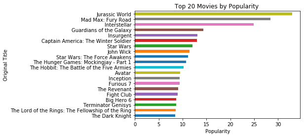

```python
movie_data.set_index('original_title')['popularity'].sort_values()[-20:].plot(kind='barh')
plt.xlabel('Popularity')
plt.ylabel('Original Title')
plt.title('Top 20 Movies by Popularity ');
```

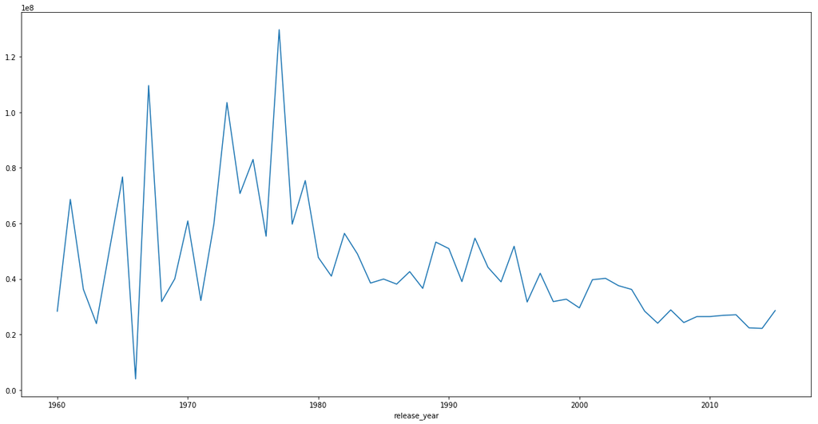

```python
#票房减成本
new_data['profit'] = new_data['revenue_adj']-new_data['budget_adj']
#以年为分组，统计年平均净利润
new_data.groupby('release_year')['profit'].mean().plot(kind='line', figsize=(20, 10));
```

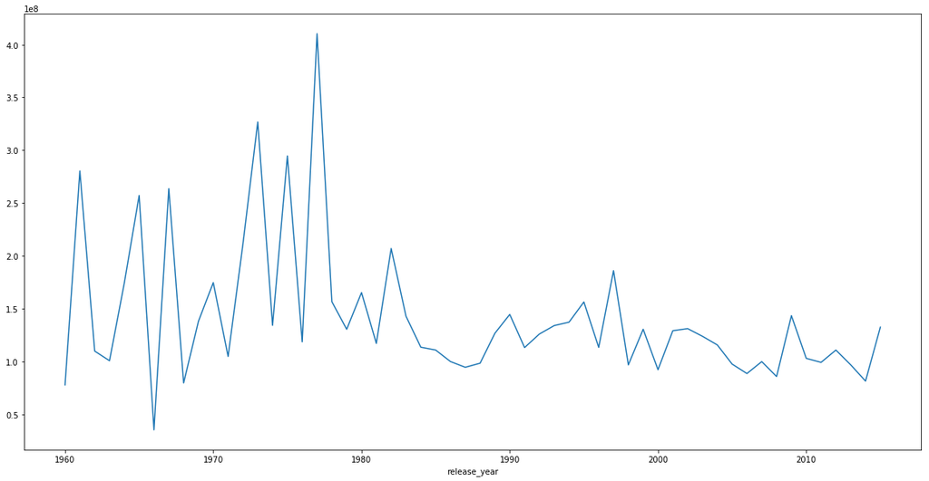

```python
#标准差
new_data.groupby('release_year')['profit'].std().plot(kind='line', figsize=(20, 10));
```

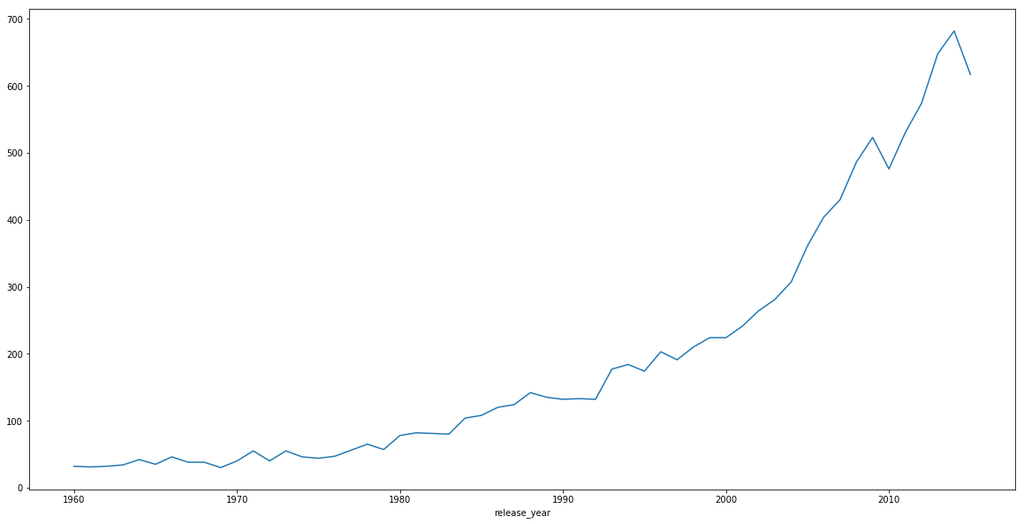

```python
#年发行量
new_data.groupby('release_year')['original_title'].count().plot(kind='line', figsize=(20, 10));
```

```python
#电影年平均利润在1979年前有较大波动，后逐渐递减，趋于缓和
#随着电影发行数量逐年增加，平均每部电影的利润在减小
```

**[选做]任务3.3：**选择最多产的10位导演（电影数量最多的），绘制他们排行前3的三部电影的票房情况，并简要进行分析。

```python
#选择最多产的10位导演（电影数量最多的）
#首先我们需要拆分同一部电影的多个导演:
tmp = movie_data['director'].str.split('|', expand=True).stack().reset_index(level=1, drop=True).rename('director')
movie_data_split = movie_data[['original_title', 'revenue']].join(tmp)
movie_data_split.groupby(movie_data_split['director'])['original_title'].count().sort_values(ascending=False).head(10)
```

```
director
Woody Allen          46
Clint Eastwood       34
Martin Scorsese      31
Steven Spielberg     30
Ridley Scott         23
Steven Soderbergh    23
Ron Howard           22
Joel Schumacher      21
Tim Burton           20
Brian De Palma       20
Name: original_title, dtype: int64
```

```python
directors = list(movie_data_split.groupby(movie_data_split['director'])['original_title'].count().sort_values(ascending=False).head(10).index)
f1, f2, f3, f4 = [],[],[],[]
for director in directors:
    #每个导演 top 3 的电影，分别取出电影名称、票房、导演、评价
    a = list(new_data[(new_data['director']== director)]['vote_average'].sort_values(ascending=False)[0:3].rename(index = new_data['original_title']).index)
    b = list(new_data[(new_data['director']== director)]['vote_average'].sort_values(ascending=False)[0:3].rename(index = new_data['revenue_adj']).index)
    c = list(new_data[(new_data['director']== director)]['vote_average'].sort_values(ascending=False)[0:3].rename(index = new_data['director']).index)
    d = list(new_data[(new_data['director']== director)]['vote_average'].sort_values(ascending=False)[0:3].rename(index = new_data['vote_average']).index)
    f1 += a
    f2 += b
    f3 += c
    f4 += d
items = {'director': pd.Series(f3),'original_title': pd.Series(f1), 'revenue_adj': pd.Series(f2),'vote_average': pd.Series(f4)}
df = pd.DataFrame(items)
#将导演设置为索引
df.set_index('director',inplace = True)
df
```

| director | original_title | revenue_adj | vote_average |
| --- | --- | --- | --- |
| Woody Allen | Manhattan | 1.200223e+08 | 7.7 |
| Woody Allen | Annie Hall | 1.376203e+08 | 7.6 |
| Woody Allen | Hannah and Her Sisters | 7.974345e+07 | 7.3 |
| Clint Eastwood | Million Dollar Baby | 2.502418e+08 | 7.6 |
| Clint Eastwood | Gran Torino | 2.734101e+08 | 7.6 |
| Clint Eastwood | Unforgiven | 2.473345e+08 | 7.5 |
| Martin Scorsese | The Last Waltz | 1.076189e+06 | 8.0 |
| Martin Scorsese | Goodfellas | 7.816519e+07 | 8.0 |
| Martin Scorsese | George Harrison: Living in the Material World | 0.000000e+00 | 8.0 |
| Steven Spielberg | Schindler's List | 4.849410e+08 | 8.1 |
| Steven Spielberg | Saving Private Ryan | 6.445564e+08 | 7.7 |
| Steven Spielberg | Catch Me If You Can | 4.268546e+08 | 7.6 |
| Ridley Scott | Blade Runner | 7.404548e+07 | 7.7 |
| Ridley Scott | Gladiator | 5.795065e+08 | 7.7 |
| Ridley Scott | The Martian | 5.477497e+08 | 7.6 |
| Steven Soderbergh | Ocean's Eleven | 5.550528e+08 | 7.0 |
| Steven Soderbergh | Erin Brockovich | 3.245143e+08 | 6.9 |
| Steven Soderbergh | The Limey | 4.179939e+06 | 6.6 |
| Ron Howard | Rush | 8.447479e+07 | 7.7 |
| Ron Howard | A Beautiful Mind | 3.861237e+08 | 7.5 |
| Ron Howard | Apollo 13 | 5.083337e+08 | 7.1 |
| Joel Schumacher | Falling Down | 6.174274e+07 | 7.0 |
| Joel Schumacher | A Time to Kill | 2.116828e+08 | 7.0 |
| Joel Schumacher | The Phantom of the Opera | 1.785337e+08 | 6.8 |
| Tim Burton | Vincent | 0.000000e+00 | 7.9 |
| Tim Burton | Edward Scissorhands | 8.845162e+07 | 7.4 |
| Tim Burton | Big Fish | 1.457024e+08 | 7.4 |
| Brian De Palma | Scarface | 1.442422e+08 | 7.8 |
| Brian De Palma | Phantom of the Paradise | 0.000000e+00 | 7.5 |
| Brian De Palma | The Untouchables | 1.463691e+08 | 7.5 |

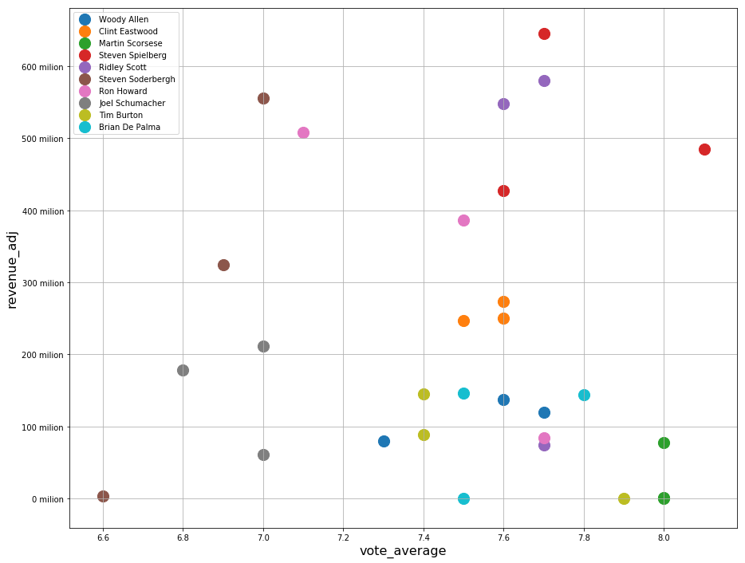

```python
#绘制票房与评价散点图
plt.figure(figsize=(15,12))
for i in range(int(len(df)/3)):
    plt.scatter(data = df, x= df['vote_average'][3*i:3*i+3],y = df['revenue_adj'][3*i:3*i+3], s = 200, label = directors[i])
#调整坐标
plt.yticks(np.linspace(0, 6, 7)*1e8,[str(int(i))+' milion' for i in np.linspace(0,600,7)])
plt.xlabel('vote_average',fontsize = 16)
plt.ylabel('revenue_adj',fontsize = 16)
plt.grid(True)
#绘制图例
plt.legend(loc='upper left')
plt.show()
```

```python
df.corr()
#存在叫好又叫座的电影，又存在评价较高的非盈利电影
#Steven Spielberg 导演的电影叫好又叫座，而且是高产导演；
#Martin Scorsese 导演的作品评价较高，但盈利性较差
#Clint Eastwood 导演的作品在评价和盈利上保持了相当稳定的水准
#Ron Howard 导演3部作品评价差别最大
#由相关性可知，票房和评价几乎没有线性相关性
```

|  | revenue_adj | vote_average |
| --- | --- | --- |
| revenue_adj | 1.000000 | -0.043753 |
| vote_average | -0.043753 | 1.000000 |

**[选做]任务3.4：**分析1968年~2015年六月电影的数量的变化。

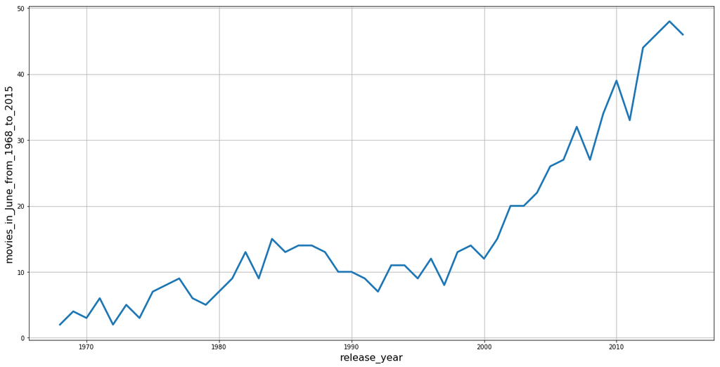

```python
#获取1968年~2015年
sel_year = new_data['release_year'].between(1968,2015,inclusive = True)
#获取6月份
sel_june = list(map(lambda x: (pd.to_datetime(x).month) == 6, new_data['release_date']))

new_data[sel_year&sel_june]['release_year'].value_counts().sort_index().plot(kind='line', figsize=(20, 10), lw = 3);

plt.xlabel('release_year', fontsize = 16);
plt.ylabel('movies_in_June_from_1968_to_2015', fontsize = 16);
plt.grid(True)
```

```python
#1968年~2015年六月电影的数量的变化:大体上为上升趋势，短时期内有回落现象，且进入2000后上升趋势加快
```

**[选做]任务3.5：**分析1968年~2015年六月电影 `Comedy` 和 `Drama` 两类电影的数量的变化。

```python
new_data['genres'].head()
```

```
0    Action|Adventure|Science Fiction|Thriller
1    Action|Adventure|Science Fiction|Thriller
2           Adventure|Science Fiction|Thriller
3     Action|Adventure|Science Fiction|Fantasy
4                        Action|Crime|Thriller
Name: genres, dtype: object
```

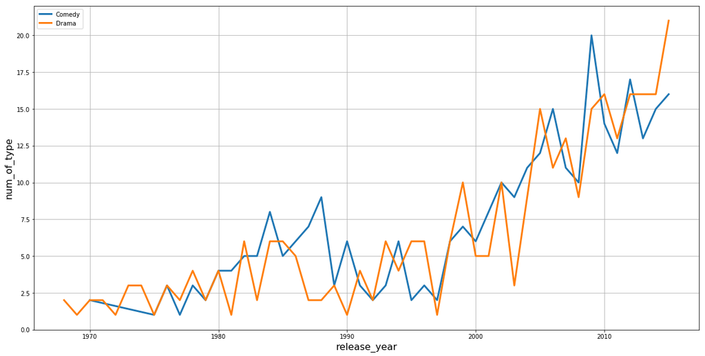

```python
#选择标签为 Comedy 的
sel_comedy = new_data['genres'].str.contains('Comedy')
#选择标签为 Drama 的
sel_drama = new_data['genres'].str.contains('Drama')
new_data[sel_year&sel_june&sel_comedy]['release_year'].value_counts().sort_index().plot(kind='line', figsize=(20, 10), lw = 3, label = 'Comedy');
new_data[sel_year&sel_june&sel_drama]['release_year'].value_counts().sort_index().plot(kind='line', figsize=(20, 10),lw = 3,label = 'Drama');
plt.grid(True)
plt.xlabel('release_year',fontsize = 16)
plt.ylabel('num_of_type',fontsize = 16)
plt.legend(loc='upper left')
plt.show()
```

```python
# Comedy 与 Drama 两类电影的发行量在时间上有较高的相关性
```

> 注意: 当你写完了所有的代码，并且回答了所有的问题。你就可以把你的 iPython Notebook 导出成 HTML 文件。你可以在菜单栏，这样导出**File -> Download as -> HTML (.html)、Python (.py)** 把导出的 HTML、python文件 和这个 iPython notebook 一起提交给审阅者。